# MATH 106 - Applied Linear Statistical Models

mbanuelos22@csufresno.edu

## Linear Regression Preliminaries

- Notation
- Residual sum of squares (RSS)

## Notation (cont.)

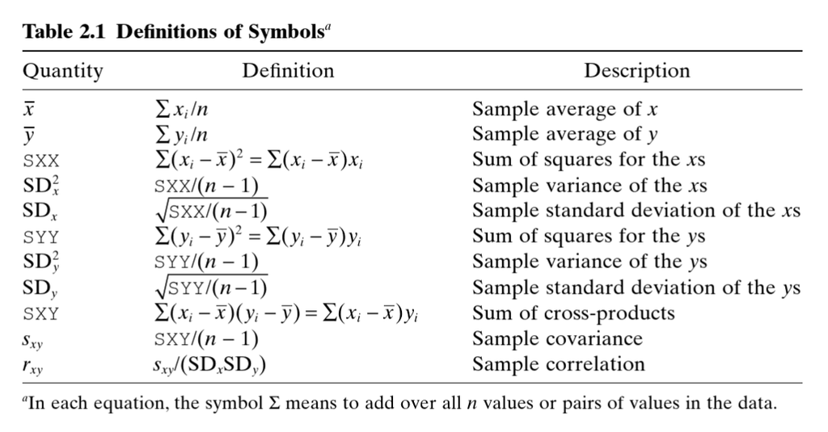

## Residual Sum of Squares

- \(e_i\) will represent the residual, \[ e_i =\text{ data } - \text{ prediction } = y_i - \beta_0 - \beta_1 x_i \]
- **Goal:** Minimize the error between prediction and data!
- The **residual sum of squares** is defined as \[ \sum_{i=1}^n (y_i - \beta_0 - \beta_1 x)^2 \]

## Residual Sum of Squares

The **ordinary least squares** line solves the following problem \[ \begin{align*} \underset{\beta_0, \beta_1 \in \mathbb{R}}{\min} \sum_{i=1}^{n} \left( y_i - \beta_0 - \beta_1 x\right)^2 \end{align*} \]

**Q:** I have 100 feet of fence material and I want to maximize the area the fence encloses.

*Note: the property has a river on one side.* What is the length and width of the fence?

## RSS (continued)

We can apply the same technique as the fence problem and differentiate with respect to one variable at a time. \[ \begin{align*} \frac{\partial \texttt{RSS}(\beta_0, \beta_1)}{\beta_0} &= -2 \sum_{i=1}^{n} (y_i - \beta_0 - \beta_1 x_i) = 0\\ \frac{\partial \texttt{RSS}(\beta_0, \beta_1)}{\beta_1} &= -2 \sum_{i=1}^{n} x_i (y_i - \beta_0 - \beta_1 x_i) = 0.\\ \end{align*} \]

## RSS (continued)

Rearranging terms, we obtain \[ \begin{align*} \beta_0 n + \beta_1 \sum x_i &= \sum y_i\\ \beta_0 \sum x_i + \beta_1 \sum x_i^2 &= \sum x_i y_i, \end{align*} \] which are called the **normal equations** for the simple linear regression model.

## Practice

**Class Activity:** For the following data, plot the data and calculate \(\hat{\beta}_0\) and \(\hat{\beta}_1\),

(1,6)

(2,5)

(3,7)

(4,10)

## RSS (cont.)

Solving for \(\beta_0\) and \(\beta_1\) in general, we have \[ \hat{\beta}_0 = \bar{y} - \hat{\beta_1} \bar{x}, \quad \hat{\beta}_1 = \frac{\texttt{SXY}}{\texttt{SXX}} \]